# Курс Stepik. Этап 1

Прохождение обучающего курса на платформе Stepik

Лебедев Сергей Алексеевич

Российский университет дружбы народов (РУДН)

2026-04-25

## Титульный слайд

**Дисциплина:** Архитектура компьютеров и операционные системы (раздел «Операционные системы»)  
**Работа:** Курс Stepik. Этап 1 – Прохождение обучающего курса на платформе Stepik

**Студент:** Лебедев Сергей Алексеевич  
**Преподаватель:** Кулябов Дмитрий Сергеевич, д.ф.-м.н., профессор  
**Организация:** Российский университет дружбы народов (РУДН)

## Содержание

1. Цель и задачи работы
2. Шаги 1-3: ОС, виртуальная машина, запуск Linux
3. Шаги 4-8: пакеты, Update Manager, терминал
4. Шаги 9-12: команды pwd, ls, rm
5. Шаги 13-15: процессы и перенаправление
6. Шаги 16-18: потоки ввода/вывода
7. Шаги 19-21: wget и загрузка файлов
8. Шаги 22-27: архивы, grep, маски
9. Выводы

## Информация о докладчике

- **Лебедев Сергей Алексеевич**
- студент направления **02.03.00 Компьютерные и информационные науки**
- РУДН, 1 курс
- Курс Stepik, этап 1: основы Linux

[figure not shown]

## Цель работы

Пройти первую часть обучающего курса на платформе Stepik, посвящённого основам работы с операционной системой Linux: установке, базовым командам терминала, работе с файлами и архивами.

## Задачи

1. Ответить на вопросы по темам: виртуальные машины, пакетный менеджер, командная строка
2. Освоить команды навигации по файловой системе (`pwd`, `ls`, `rm`)
3. Изучить управление процессами и фоновый запуск программ
4. Разобрать перенаправление потоков ввода/вывода
5. Изучить загрузку файлов с помощью `wget`
6. Освоить архивирование (`gzip`, `zip`, `tar`) и поиск по маскам

## Шаг 1. Используемая ОС

Вопрос о текущей операционной системе. Выбран ответ **OS X** - работа ведётся на macOS. Ответ засчитан как верный.

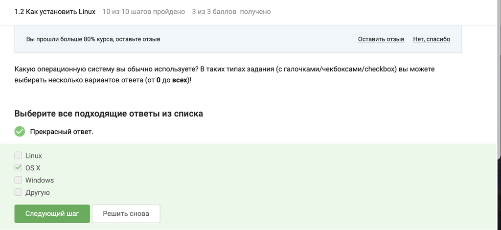

Вопрос об операционной системе

## Шаг 2. Что такое виртуальная машина

Вопрос с одним верным ответом. Выбран вариант: **специальная программа для запуска одной ОС на другой ОС**.

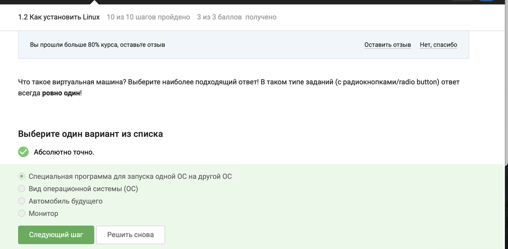

Вопрос о виртуальной машине

## Шаг 3. Запуск Linux

Вопрос: удалось ли запустить Linux на своём компьютере. Выбран ответ **Да**.

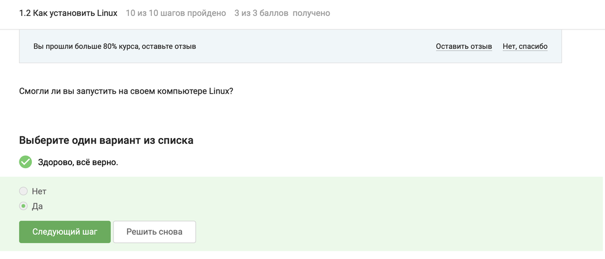

Вопрос о запуске Linux

## Шаги 4-6: пакеты и разработчик

**Шаг 4** - практическое задание: создан файл `hello_linux.fodt`.

**Шаг 5** - расширение пакетов в Linux-дистрибутивах семейства Debian: **deb**.

**Шаг 6** - определение имени разработчика по контексту: **Denis-Courmont**.

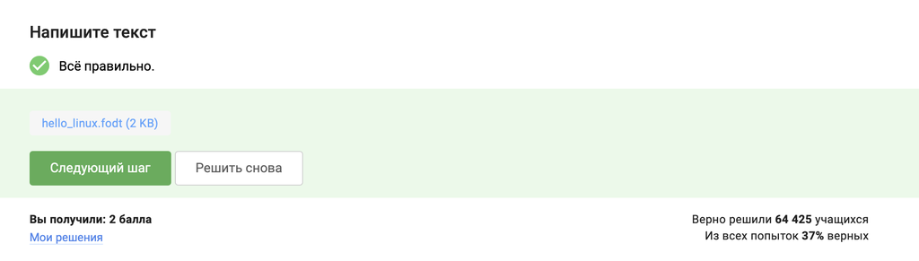

Практическое задание hello_linux.fodt

## Шаг 7. Назначение Update Manager

Вопрос с несколькими верными ответами. Выбраны:

- для обновления установленных программ ✔
- для обновления всей системы ✔
- для обновления ссылок ✔

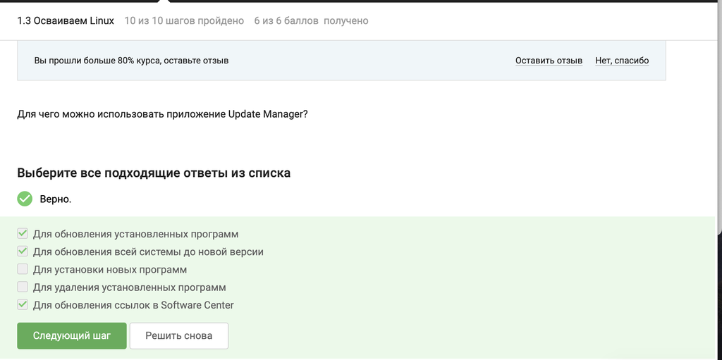

Вопрос о назначении Update Manager

## Шаг 8. Синонимы командной строки

Вопрос о синонимах понятия «командная строка». Верные варианты: **Терминал** и **Консоль**.

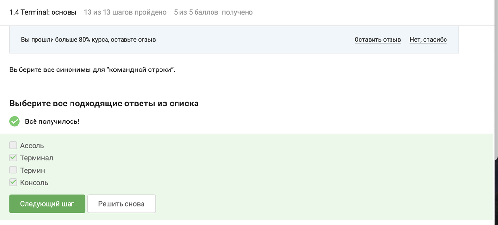

Вопрос о синонимах командной строки

## Шаг 9. Команда pwd

Вопрос о корректной форме записи команды вывода текущей директории. Верный ответ: **только `pwd`** - Linux чувствительна к регистру.

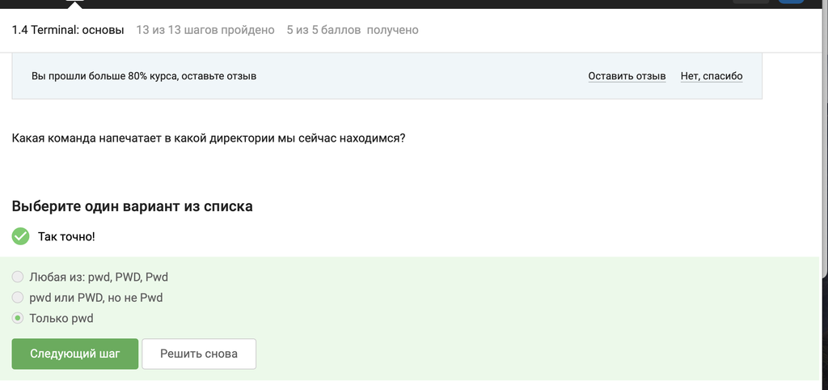

Вопрос о команде pwd

## Шаг 10. Команда ls с опциями

Верные варианты записи команды `ls` с опциями `-l`, `-A`, `-h`:

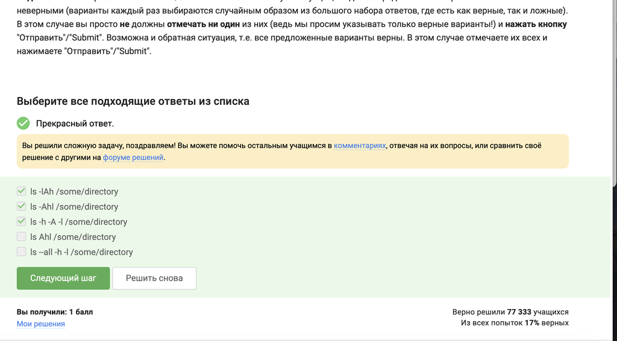

Вопрос о команде ls с опциями

```bash
ls -lAh /some/directory
ls -Ahl /some/directory
ls -h -A -l /some/directory
```

## Шаги 11-12: файловая система

**Шаг 11** - корректные способы обратиться к `Downloads`:

```bash
ls ~/Downloads
ls /home/bi/Downloads
```

**Шаг 12** - команда для рекурсивного удаления директорий: **`rm -r`**.

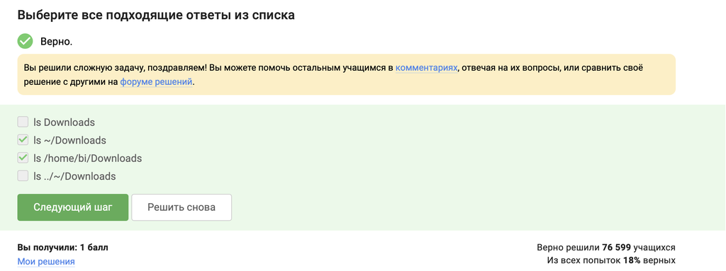

Вопрос о доступе к каталогу Downloads

## Шаги 13-14: управление процессами

**Шаг 13** - при закрытии терминала Firefox, запущенный в фоне, не закроется: **никто не закроется**.

**Шаг 14** - перевод программы в фоновый режим: **запуск, Ctrl+Z, bg**.

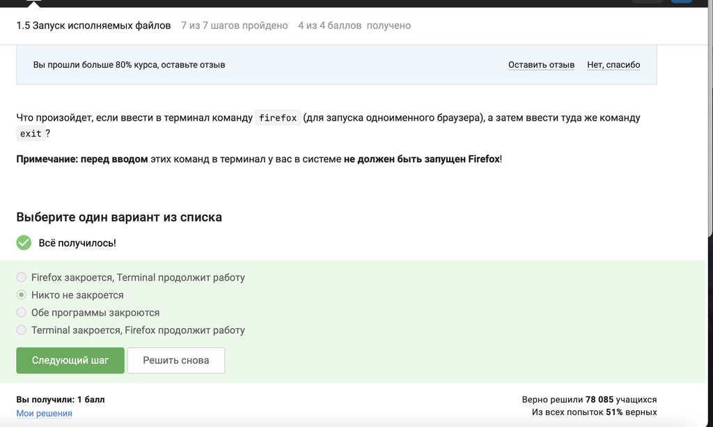

Вопрос о поведении программ

## Шаг 15. Результат выполнения команды

Практическое задание: определить результат выполнения команды. Введён верный ответ:

```
2026-04-25 12:54:00
Control sum: 943
```

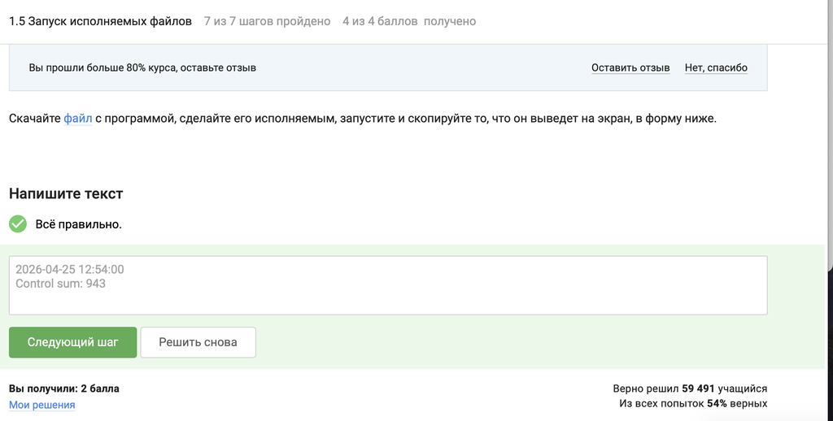

Практическое задание на вывод результата

## Шаги 16-17: потоки ошибок

**Шаг 16** - куда выводятся ошибки по умолчанию: **на экран** (stderr направлен в терминал).

**Шаг 17** - при перенаправлении stdout в файл ошибки по-прежнему **выводятся на экран**, так как stderr и stdout – отдельные потоки.

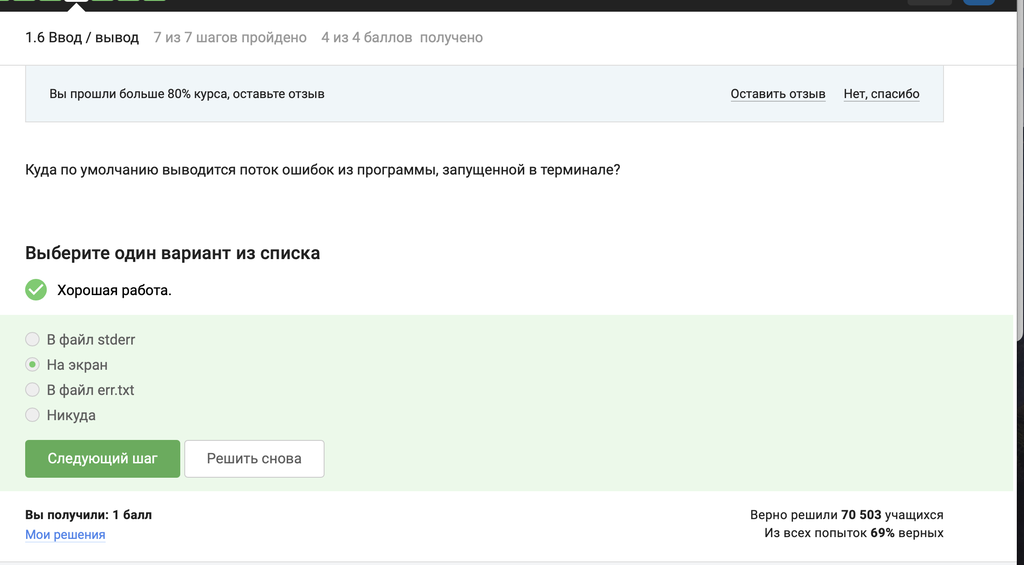

Вопрос о потоке ошибок

## Шаг 18. Перенаправление stderr

Верные варианты для перенаправления потока ошибок:

[figure not shown]

```bash
program 2>> file.txt   # дозапись stderr
program 2> file.txt    # перезапись stderr
```

## Шаги 19-20: wget

**Шаг 19** - файл окажется по пути: `/home/alex/1.jpg`.

**Шаг 20** - опция `wget` для полного отключения вывода: **`-q`** (quiet).

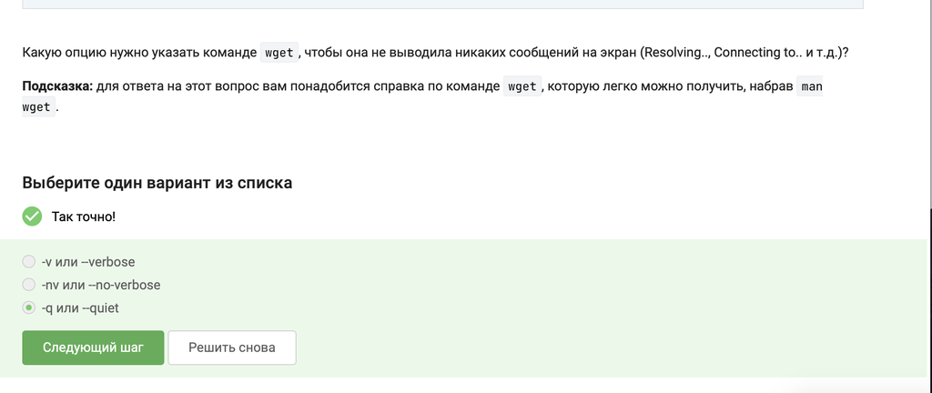

Вопрос об опции wget

## Шаг 21. Результат загрузки wget с фильтрацией

Верный ответ: **jpg и html, html удалятся** - html-файлы используются только для разбора ссылок и затем удаляются.

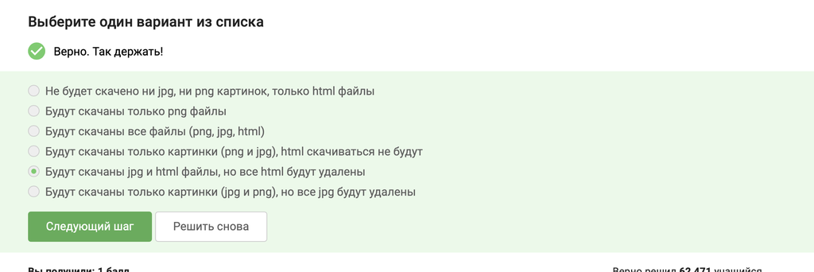

Вопрос о результате загрузки wget

## Шаги 22-24: архивы

**Шаг 22** - отличие gzip от zip: **gzip удаляет исходный файл** после архивирования.

**Шаг 23** - архиваторы, работающие с несколькими файлами: **tar** и **zip**.

**Шаг 24** - флаг для создания `.tar.bz2`: **`-cjf`** (`c` - создать, `j` - bzip2, `f` - файл).

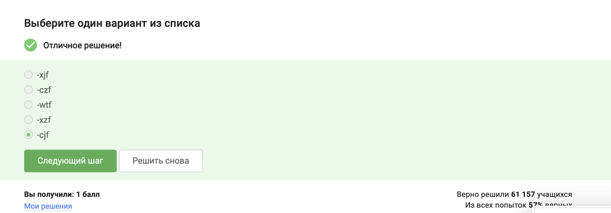

Вопрос о флаге tar

## Шаг 25. Строки, соответствующие grep-шаблону

Верные варианты:

- `The "world" is not enough` ✔
- `The world is not enough` ✔
- `The beautiful-world is not enough` ✔
- `The beautifulworld is not enough` ✔
- `world` ✔

[figure not shown]

## Шаги 26-27: маски и итоговое задание

**Шаг 27** - финальное практическое задание: создан файл `love_lines.txt`. Первая часть курса завершена.

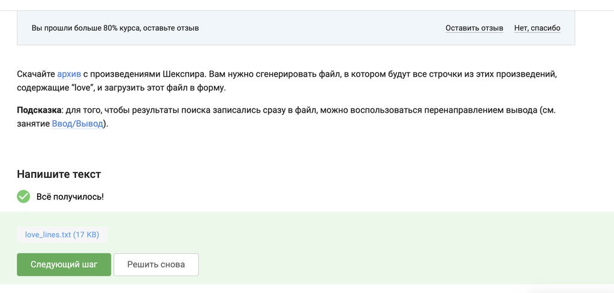

Итоговое практическое задание

## Ресурсы

- Курс на платформе Stepik: https://stepik.org
- GNU Bash Reference Manual: https://www.gnu.org/software/bash/manual/
- Linux man-pages: https://man7.org/linux/man-pages/
- GitHub: https://github.com/lebedev-s-a